# ThesisSurveyCluster

04 June, 2021

[figure not shown]

# Clustering & Correspondence analysis

**Steps:** 1. Decide which columns to use, decide coding to get homogeneous for clustering

2. Clustering

3. Correspondence analysis, bring in demographics.

4. Individual cluster analysis - sub-sample

## Loading datasets & Packages

[Reference to Methodology applied.](https://towardsdatascience.com/k-means-clustering-algorithm-applications-evaluation-methods-and-drawbacks-aa03e644b48a)

### Transforming variables

Primarily several multi-option variables are removed from the data set. Next dummies are created for the categorical variables.

If the option is not selected, the answer corresponds with 0.  
If the option has been selected, the answer corresponds with 1.

```r
data <- separate(
  data,
  Criteria_Type_Coffee,
  into = c("Criteria_A", "Criteria_B"),
  sep = "([,])",
  remove = TRUE,
  convert = FALSE,
  extra = "drop",
  fill = "right",
)

data <- separate(
  data,
  Subscription_Not_Likely,
  into = c("Subscription_A", "Subscription_B"),
  sep = "([,])",
  remove = TRUE,
  convert = FALSE,
  extra = "drop",
  fill = "right",
)

data <- separate(
  data,
  "Supermarket_Negative_ Reasons",
  into = c("Supermarket_NO_A", "Supermarket_NO_B"),
  sep = "([,])",
  remove = TRUE,
  convert = FALSE,
  extra = "drop",
  fill = "right",
)

data <- separate(
  data,
  "Supermarket_Positive_ Reasons",
  into = c("Supermarket_YES_A", "Supermarket_YES_B"),
  sep = "([,])",
  remove = TRUE,
  convert = FALSE,
  extra = "drop",
  fill = "right",
)
```

### One-hot Encoding

The variables selected for clustering are: 1. Purchase Location 2. Frequency Specialty coffee consumption 3. Amount brand change 4. Amount consumed per week 5. Money spend on coffee 6. Likeliness to set up and app 7. Likeliness to set up and subscription

```r
# "AmountWeek", "MoneyCoffee"
```

Separate the second, responses to 0.1. Do not categorize on demographics together with the preferences. Everything to do with coffee has to be in cluster analysis.

Which variables to use

```r
#BrandChange, PurchaseLocation, App_Likely, Subscription_Likely,
```

## Clustering including categorical variables

The next step is to remove this missing variables (NA), standardize the numerical variables and combine to make the new data table to be used for the cluster analysis.

```r
# Prepare Data
Orgdata <- na.omit(dataf[,c(11:23)]) # listwise deletion of missing
stdata <- scale(dataf[,c(0:10)]) # standardize variables
NewData <- cbind(Orgdata, stdata)
```

```r
names(NewData)
```

```
 [1] "BrandChange_Every time"
 [2] "BrandChange_Never"
 [3] "BrandChange_Sometimes"
 [4] "BrandChange_Very often"
 [5] "PurchaseLocation_E-commerce"
 [6] "PurchaseLocation_Online subscription"
 [7] "PurchaseLocation_Specialty stores or cafés"
 [8] "PurchaseLocation_The supermarket"
 [9] "Frequency_Specialty_Always"
[10] "Frequency_Specialty_I do (did) not know what this is"
[11] "Frequency_Specialty_Never"
[12] "Frequency_Specialty_Only in cafes"
[13] "Frequency_Specialty_Sometimes"
[14] "AmountWeek"
[15] "MoneyCoffee"
[16] "KnowledgeCoffee"
[17] "Purchase_Price"
[18] "Purchase_Sustainability"
[19] "Purchase_Certificate"
[20] "Purchase_Fairtrade"
[21] "Purchase_Packaging"
[22] "Subscription_Likely"
[23] "App_Likely"
```

### Correlation Matrix

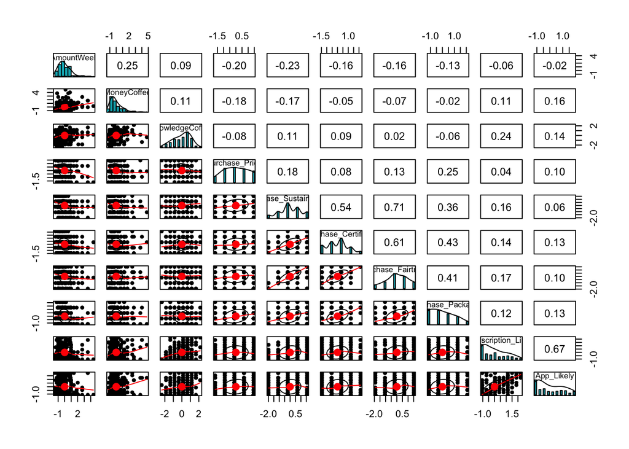

## Performing clusters

```r
set.seed(1234)

# K-Means Cluster Analysis
fit <- kmeans(na.omit(NewData), centers = 4, nstart = 50) #4 cluster solution
fit$betweenss/fit$totss
```

```
[1] 0.2881619
```

```r
fit2 <- kmeans(na.omit(NewData), centers = 3, nstart = 50) #3 cluster solution
fit2$betweenss/fit2$totss
```

```
[1] 0.2388196
```

```r
fit3 <- kmeans(na.omit(NewData), centers = 2, nstart = 50) #2 cluster solution
fit3$betweenss/fit3$totss
```

```
[1] 0.1660102
```

```r
fit4 <- kmeans(na.omit(NewData), centers =1, nstart = 50) #1 cluster solution
fit4$betweenss/fit4$totss
```

```
[1] 0.00000000000002368555
```

% between-group variance:

## Finding optimal number of clusters

• SOLUTION: Repeat the algorithm repeatedly from different starting seeds and choose the best solution. Often there are several identical best solutions from different starting points.

• The algorithm applies to a pre-defined number of clusters. How many clusters should be retained?

• SOLUTION: Repeat the whole process on different numbers of clusters, compare the solutions and decide what appears to be an empirically justified number of clusters, combined on domain knowledge domain knowledge.

```r
## looping on k-means algorithm to decide how many clusters
set.seed(1234)
lifestyle.BW <- rep(0, 10)
for(nc in 2:10) {
  lifestyle.km <- kmeans(NewData, centers=nc, nstart=20, iter.max=200)
  lifestyle.BW[nc] <- lifestyle.km$betweenss/lifestyle.km$totss
}
lifestyle.BW
```

```
 [1] 0.0000000 0.1660102 0.2388196 0.2881619 0.3242922 0.3562143 0.3783748
 [8] 0.4057495 0.4246262 0.4426855
```

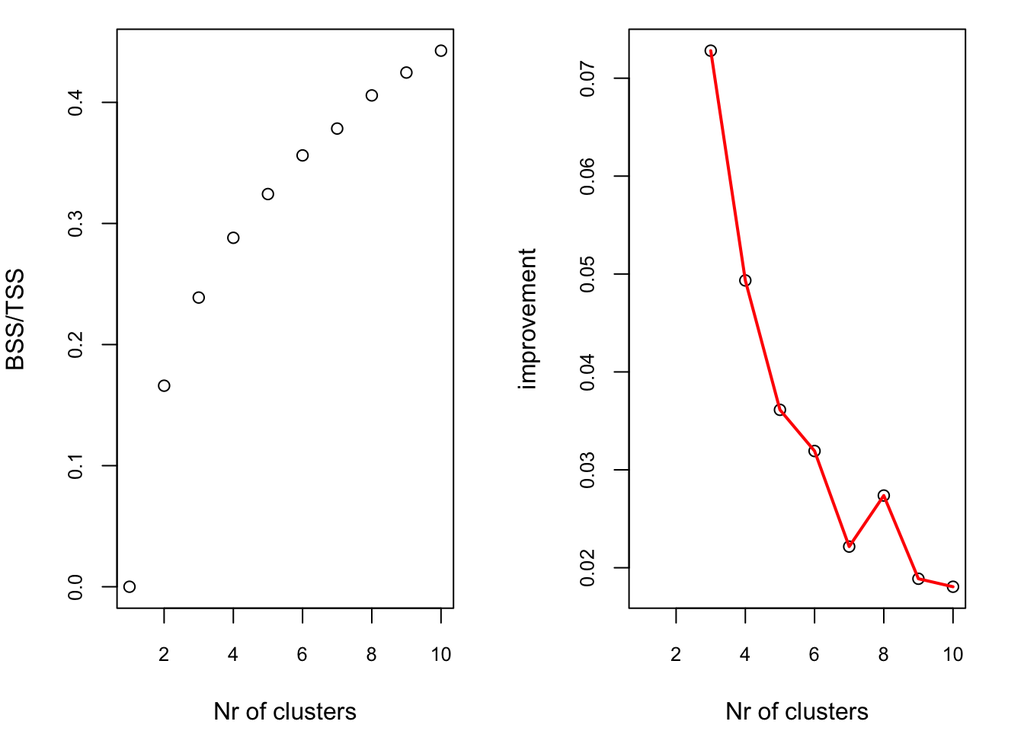

```r
## plot the proportion of between-cluster variance
par(mar=c(4.2,4,1,2), cex.axis=0.8, mfrow=c(1,2))
plot(lifestyle.BW, xlab="Nr of clusters", ylab="BSS/TSS")

## plot the increments in between-cluster variance
lifestyle.BWinc <- lifestyle.BW[2:10]-lifestyle.BW[1:9]
plot(1:10, c(NA,NA, lifestyle.BWinc[2:9]), xlab="Nr of clusters", ylab="improvement")
lines(3:10, lifestyle.BWinc[2:9], col="red", lwd=2)
```

### Elbow method

**Distance**

```r
NewData <- na.omit(NewData)
distance <- get_dist(NewData)
graph <- fviz_dist(distance, gradient = list(low = "#00AFBB", mid = "white", high = "#FC4E07"))
```

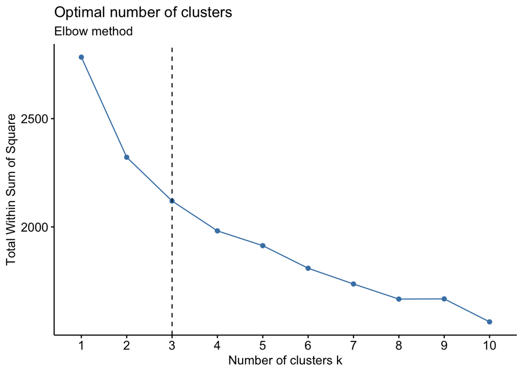

```r
library("NbClust")

# Elbow method
fviz_nbclust(NewData, kmeans, method = "wss") +
    geom_vline(xintercept = 3, linetype = 2)+
  labs(subtitle = "Elbow method")
```

### Average silhoutte method

The average silhouette approach we’ll be described comprehensively in the chapter cluster validation statistics. Briefly, it measures the quality of a clustering. That is, it determines how well each object lies within its cluster. A high average silhouette width indicates a good clustering.

Average silhouette method computes the average silhouette of observations for different values of k. The optimal number of clusters k is the one that maximize the average silhouette over a range of possible values for k (Kaufman and Rousseeuw 1990).

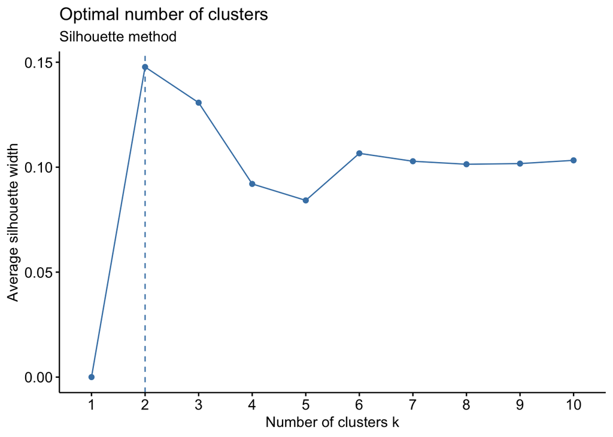

```r
# Silhouette method
fviz_nbclust(NewData, kmeans, method = "silhouette")+
  labs(subtitle = "Silhouette method")
```

```
  cluster size ave.sil.width
1       1   43          0.10
2       2   73          0.16
3       3   78          0.11
4       4   41          0.06
```

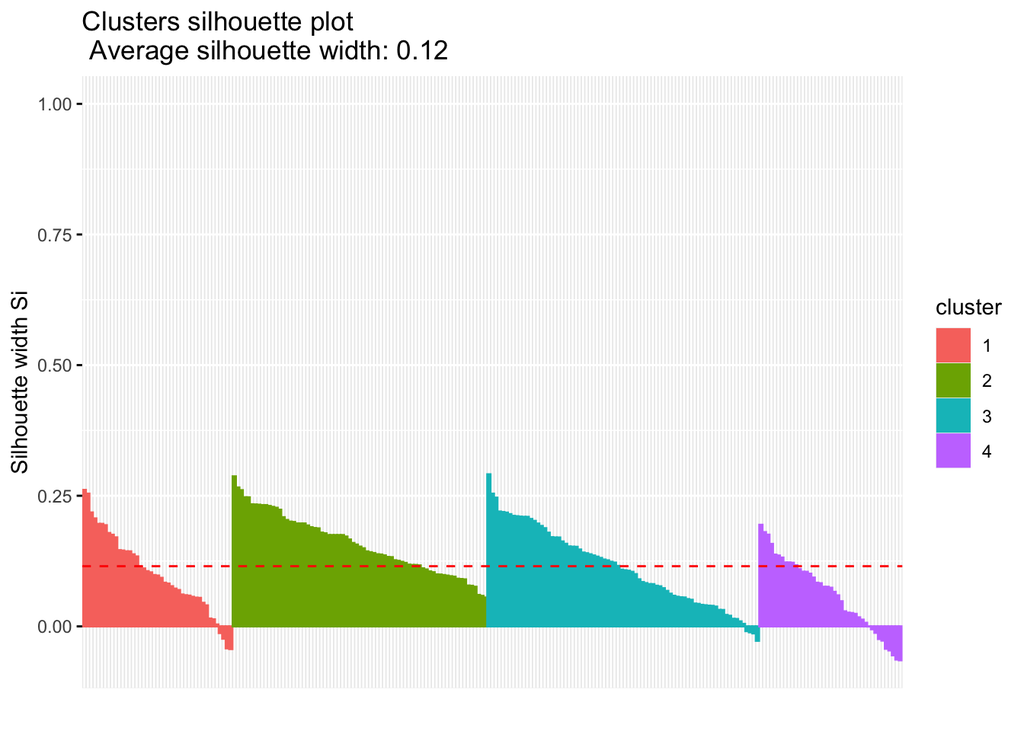

```r
sil <- silhouette(fit$cluster, dist(NewData))
fviz_silhouette(sil)
```

```
  cluster size ave.sil.width
1       1  102          0.14
2       2   74          0.10
3       3   59          0.12
```

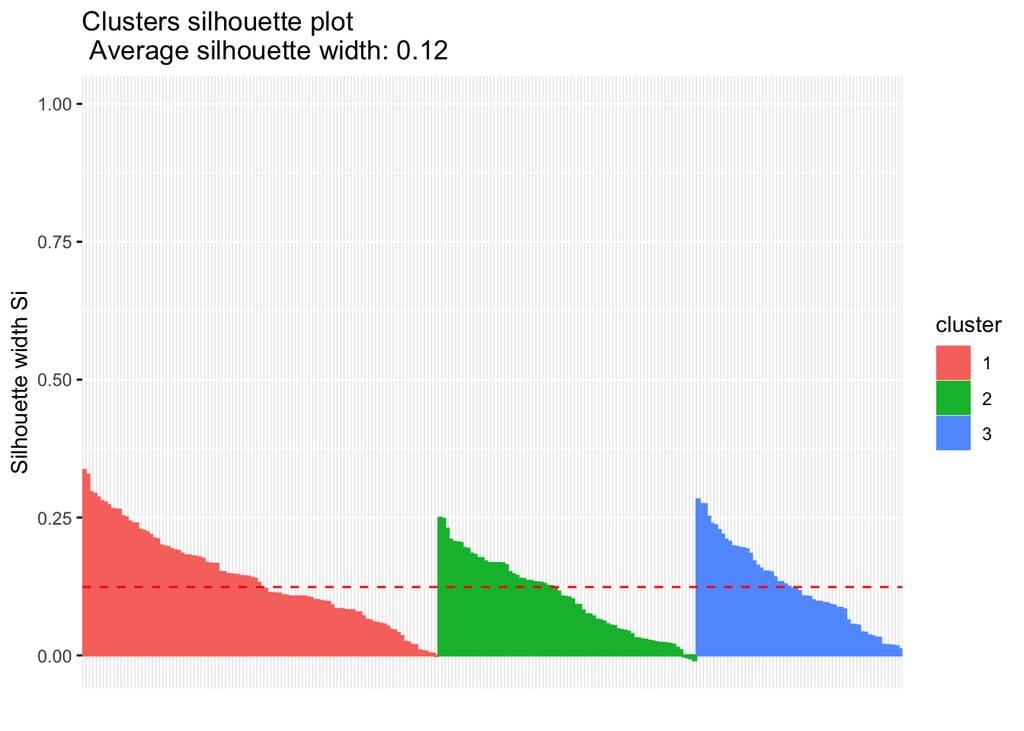

```r
sil <- silhouette(fit2$cluster, dist(NewData))
fviz_silhouette(sil)
```

```
  cluster size ave.sil.width
1       1  120          0.14
2       2  115          0.16
```

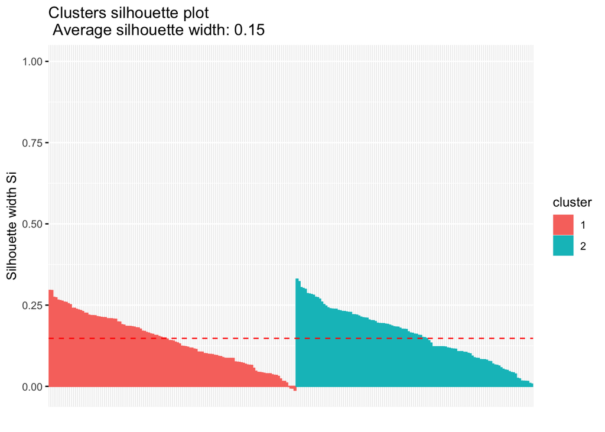

```r
sil <- silhouette(fit3$cluster, dist(NewData))
fviz_silhouette(sil)
```

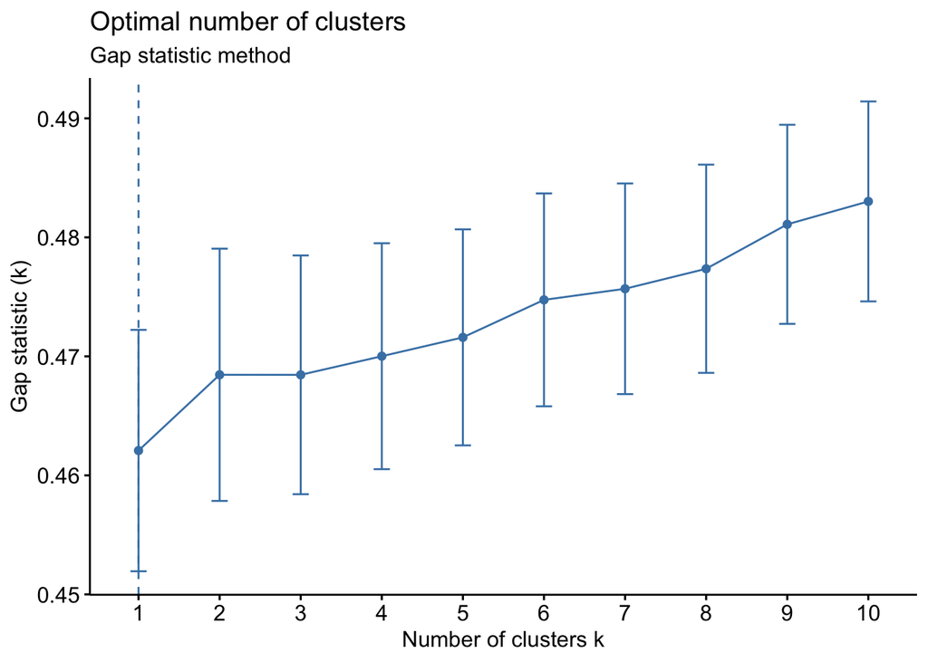

```r
# Gap statistic
# nboot = 50 to keep the function speedy.
# recommended value: nboot= 500 for your analysis.
# Use verbose = FALSE to hide computing progression.
set.seed(123)
fviz_nbclust(NewData, kmeans, nstart = 25,  method = "gap_stat", nboot = 50, verbose = FALSE)+
  labs(subtitle = "Gap statistic method")
```

http://web.stanford.edu/~hastie/Papers/gap.pdf

http://www.datanovia.com/en/lessons/determining-the-optimal-number-of-clusters-3-must-know-methods/#at_pco=wnm-1.0&at_si=609664423560aa01&at_ab=per-2&at_pos=0&at_tot=1

**Adding cluster classification to the original data set**

```r
# append cluster assignment
mydata <- data.frame(na.omit(dataf), cluster = fit$cluster)
```

**Getting cluster means:**

```r
fitMeans <- aggregate(mydata,
  by=list(cluster = fit2$cluster),
  FUN=mean
  )

fitMeans <- round(fitMeans,1)
my_table(fitMeans)
```

| cluster | AmountWeek | MoneyCoffee | KnowledgeCoffee | Purchase_Price | Purchase_Sustainability | Purchase_Certificate | Purchase_Fairtrade | Purchase_Packaging | Subscription_Likely | App_Likely | BrandChange_Every.time | BrandChange_Never | BrandChange_Sometimes | BrandChange_Very.often | PurchaseLocation_E.commerce | PurchaseLocation_Online.subscription | PurchaseLocation_Specialty.stores.or.cafés | PurchaseLocation_The.supermarket | Frequency_Specialty_Always | Frequency_Specialty_I.do..did..not.know.what.this.is | Frequency_Specialty_Never | Frequency_Specialty_Only.in.cafes | Frequency_Specialty_Sometimes | cluster |
| --- | --- | --- | --- | --- | --- | --- | --- | --- | --- | --- | --- | --- | --- | --- | --- | --- | --- | --- | --- | --- | --- | --- | --- | --- |
| 1 | 22.3 | 25.7 | 5.4 | 2.8 | 2.4 | 1.9 | 2.4 | 1.7 | 2.4 | 3.1 | 0 | 0.4 | 0.6 | 0.0 | 0.2 | 0.0 | 0.0 | 0.8 | 0.0 | 0.3 | 0.2 | 0.2 | 0.2 | 2.8 |
| 2 | 17.9 | 31.2 | 6.6 | 3.4 | 3.6 | 3.0 | 3.7 | 2.8 | 6.9 | 7.1 | 0 | 0.2 | 0.6 | 0.1 | 0.2 | 0.1 | 0.2 | 0.4 | 0.2 | 0.1 | 0.1 | 0.2 | 0.4 | 3.0 |
| 3 | 12.6 | 17.5 | 5.1 | 3.4 | 4.2 | 3.5 | 4.2 | 3.1 | 2.6 | 2.9 | 0 | 0.4 | 0.5 | 0.2 | 0.2 | 0.0 | 0.1 | 0.7 | 0.1 | 0.3 | 0.2 | 0.2 | 0.2 | 1.4 |

**Getting cluster medians:**

```r
fitMeans <- aggregate(mydata,
  by=list(cluster = fit$cluster),
  FUN=median
  )

fitMeans <- round(fitMeans,1)
my_table(fitMeans)
```

| cluster | AmountWeek | MoneyCoffee | KnowledgeCoffee | Purchase_Price | Purchase_Sustainability | Purchase_Certificate | Purchase_Fairtrade | Purchase_Packaging | Subscription_Likely | App_Likely | BrandChange_Every.time | BrandChange_Never | BrandChange_Sometimes | BrandChange_Very.often | PurchaseLocation_E.commerce | PurchaseLocation_Online.subscription | PurchaseLocation_Specialty.stores.or.cafés | PurchaseLocation_The.supermarket | Frequency_Specialty_Always | Frequency_Specialty_I.do..did..not.know.what.this.is | Frequency_Specialty_Never | Frequency_Specialty_Only.in.cafes | Frequency_Specialty_Sometimes | cluster |
| --- | --- | --- | --- | --- | --- | --- | --- | --- | --- | --- | --- | --- | --- | --- | --- | --- | --- | --- | --- | --- | --- | --- | --- | --- |
| 1 | 13.0 | 15.0 | 6 | 3 | 5 | 4 | 4 | 3 | 2 | 2 | 0 | 0 | 0 | 0 | 0 | 0 | 0 | 1 | 0 | 0 | 0 | 0 | 0 | 1 |
| 2 | 14.0 | 10.0 | 5 | 4 | 3 | 2 | 3 | 2 | 2 | 2 | 0 | 0 | 1 | 0 | 0 | 0 | 0 | 1 | 0 | 0 | 0 | 0 | 0 | 2 |
| 3 | 14.5 | 22.5 | 7 | 4 | 4 | 3 | 4 | 3 | 7 | 7 | 0 | 0 | 1 | 0 | 0 | 0 | 0 | 0 | 0 | 0 | 0 | 0 | 0 | 3 |
| 4 | 28.0 | 40.0 | 6 | 2 | 2 | 2 | 2 | 1 | 2 | 3 | 0 | 1 | 0 | 0 | 0 | 0 | 0 | 1 | 0 | 0 | 0 | 0 | 0 | 4 |

```r
print(fit2)
```

```
K-means clustering with 3 clusters of sizes 102, 74, 59

Cluster means:
  BrandChange_Every time BrandChange_Never BrandChange_Sometimes
1             0.00000000         0.3823529             0.5882353
2             0.04054054         0.2162162             0.5945946
3             0.00000000         0.3728814             0.4745763
  BrandChange_Very often PurchaseLocation_E-commerce
1             0.02941176                   0.1666667
2             0.14864865                   0.1891892
3             0.15254237                   0.1525424
  PurchaseLocation_Online subscription
1                           0.02941176
2                           0.13513514
3                           0.01694915
```

[output cut: 63 more lines]

## Validation testing

https://www.datanovia.com/en/lessons/cluster-validation-statistics-must-know-methods/

Generally, clustering validation statistics can be categorized into 3 classes (Charrad et al. 2014,Brock et al. (2008), Theodoridis and Koutroumbas (2008)):

1. Internal cluster validation, which uses the internal information of the clustering process to evaluate the goodness of a clustering structure without reference to external information. It can be also used for estimating the number of clusters and the appropriate clustering algorithm without any external data.
2. External cluster validation, which consists in comparing the results of a cluster analysis to an externally known result, such as externally provided class labels. It measures the extent to which cluster labels match externally supplied class labels. Since we know the “true” cluster number in advance, this approach is mainly used for selecting the right clustering algorithm for a specific data set.
3. Relative cluster validation, which evaluates the clustering structure by varying different parameter values for the same algorithm (e.g.,: varying the number of clusters k). It’s generally used for determining the optimal number of clusters.

```r
## perform nonparametric ANOVA between-clusters to get chi-squares and p-values
var_names <- colnames(mydata[,-ncol(mydata)])

anova_tests <- list()
for (var_name in var_names) {
  anova_tests[[var_name]] <- kruskal.test(get(var_name) ~ cluster, data = mydata)
}

anova_tests
```

```
$AmountWeek

    Kruskal-Wallis rank sum test

data:  get(var_name) by cluster
Kruskal-Wallis chi-squared = 43.447, df = 3, p-value = 0.000000001978


$MoneyCoffee

    Kruskal-Wallis rank sum test

data:  get(var_name) by cluster
Kruskal-Wallis chi-squared = 64.498, df = 3, p-value =
0.00000000000006424


$KnowledgeCoffee

    Kruskal-Wallis rank sum test

data:  get(var_name) by cluster
Kruskal-Wallis chi-squared = 17.858, df = 3, p-value = 0.0004706


$Purchase_Price

    Kruskal-Wallis rank sum test

data:  get(var_name) by cluster
Kruskal-Wallis chi-squared = 43.257, df = 3, p-value = 0.00000000217


$Purchase_Sustainability

    Kruskal-Wallis rank sum test

data:  get(var_name) by cluster
Kruskal-Wallis chi-squared = 127.92, df = 3, p-value <
0.00000000000000022
```

[output cut: 133 more lines]

```

$Frequency_Specialty_Only.in.cafes

    Kruskal-Wallis rank sum test

data:  get(var_name) by cluster
Kruskal-Wallis chi-squared = 0.52388, df = 3, p-value = 0.9136


$Frequency_Specialty_Sometimes

    Kruskal-Wallis rank sum test

data:  get(var_name) by cluster
Kruskal-Wallis chi-squared = 2.7258, df = 3, p-value = 0.4359
```

```r
var_names <- colnames(mydata[,-ncol(mydata)])

anova_tests <- list()
for (var_name in var_names) {
  anova_tests[[var_name]] <- oneway.test(get(var_name) ~ cluster, data = mydata)
}

anova_tests
```

```
$AmountWeek

    One-way analysis of means (not assuming equal variances)

data:  get(var_name) and cluster
F = 13.636, num df = 3.00, denom df = 106.71, p-value = 0.0000001353


$MoneyCoffee

    One-way analysis of means (not assuming equal variances)

data:  get(var_name) and cluster
F = 21.883, num df = 3.00, denom df = 106.19, p-value =
0.00000000004136


$KnowledgeCoffee

    One-way analysis of means (not assuming equal variances)

data:  get(var_name) and cluster
F = 7.3066, num df = 3.00, denom df = 109.19, p-value = 0.0001645


$Purchase_Price

    One-way analysis of means (not assuming equal variances)

data:  get(var_name) and cluster
F = 22.371, num df = 3.00, denom df = 110.73, p-value =
0.00000000002134


$Purchase_Sustainability

    One-way analysis of means (not assuming equal variances)

data:  get(var_name) and cluster
F = 87.626, num df = 3.00, denom df = 109.79, p-value <
```

[output cut: 135 more lines]

```

$Frequency_Specialty_Only.in.cafes

    One-way analysis of means (not assuming equal variances)

data:  get(var_name) and cluster
F = 0.17192, num df = 3.00, denom df = 109.97, p-value = 0.9152


$Frequency_Specialty_Sometimes

    One-way analysis of means (not assuming equal variances)

data:  get(var_name) and cluster
F = 0.86045, num df = 3.0, denom df = 110.7, p-value = 0.464
```

**Within sum of squares:**

```r
print(fit$withinss)
```

```
[1] 374.0707 529.9048 680.1541 397.5611
```

```r
print(fit2$withinss)
```

```
[1] 938.0178 677.9900 503.0471
```

```r
print(fit3$withinss)
```

```
[1] 1202.231 1119.518
```

**Between sum of squares**

```r
print(fit$betweenss)
```

```
[1] 802.2156
```

```r
print(fit2$betweenss)
```

```
[1] 664.8514
```

```r
print(fit3$betweenss)
```

```
[1] 462.1568
```

```r
print(fit4$betweenss)
```

```
[1] 0.00000000006593837
```

**Total sum of squares**

```r
print(fit$totss)
```

```
[1] 2783.906
```

```r
print(fit2$totss)
```

```
[1] 2783.906
```

```r
print(fit3$totss)
```

```
[1] 2783.906
```

```r
cluster <- c(1:4)
t.test(fit$withinss, cluster)
```

```
    Welch Two Sample t-test

data:  fit$withinss and cluster
t = 6.993, df = 3.0005, p-value = 0.006
alternative hypothesis: true difference in means is not equal to 0
95 percent confidence interval:
 268.6193 717.2261
sample estimates:
mean of x mean of y
 495.4227    2.5000
```

```r
t.test(fit2$withinss, cluster)
```

```
    Welch Two Sample t-test

data:  fit2$withinss and cluster
t = 5.57, df = 2.0001, p-value = 0.03075
alternative hypothesis: true difference in means is not equal to 0
95 percent confidence interval:
  160.1738 1247.5295
sample estimates:
mean of x mean of y
 706.3516    2.5000
```

```r
t.test(fit3$withinss, cluster)
```

```
    Welch Two Sample t-test

data:  fit3$withinss and cluster
t = 28.006, df = 1.0005, p-value = 0.02269
alternative hypothesis: true difference in means is not equal to 0
95 percent confidence interval:
  633.431 1683.319
sample estimates:
mean of x mean of y
 1160.875     2.500
```

```r
library("fpc")
cluster.stats(d = dist(NewData), fit2$cluster)
```

```
$n
[1] 235

$cluster.number
[1] 3

$cluster.size
[1] 102  74  59

$min.cluster.size
[1] 59

$noisen
[1] 0

$diameter
[1] 7.895409 7.880855 7.003931

$average.distance
[1] 4.196440 4.197662 4.088266

$median.distance
[1] 4.164674 4.101028 4.108588

$separation
[1] 1.588872 1.588872 1.670990

$average.toother
[1] 5.122106 5.037340 4.958412

$separation.matrix
         [,1]     [,2]     [,3]
[1,] 0.000000 1.588872 1.901169
[2,] 1.588872 0.000000 1.670990
[3,] 1.901169 1.670990 0.000000

$ave.between.matrix
         [,1]     [,2]     [,3]
[1,] 0.000000 5.167806 5.064787
[2,] 5.167806 0.000000 4.811788
```

[output cut: 53 more lines]

```

$cwidegap
[1] 3.774041 4.223510 3.422740

$widestgap
[1] 4.22351

$sindex
[1] 1.896749

$corrected.rand
NULL

$vi
NULL
```

**Creating new data sets for each cluster group**

```r
data <- read_excel("Main doc survey.xlsx")
clustereddata <- cbind(data, Cluster = fit2$cluster)

cluster1 <- subset(clustereddata, clustereddata$Cluster=='1')
cluster2 <- subset(clustereddata, clustereddata$Cluster=='2')
cluster3 <- subset(clustereddata, clustereddata$Cluster=='3')
cluster4 <- subset(clustereddata, clustereddata$Cluster=='4')
```

## Visualizing clusters

Provides ggplot2-based elegant visualization of partitioning methods including kmeans [stats package]; pam, clara and fanny [cluster package]; dbscan [fpc package]; Mclust [mclust package]; HCPC [FactoMineR]; hkmeans [factoextra]. Observations are represented by points in the plot, using principal components if ncol(data) > 2. An ellipse is drawn around each cluster.

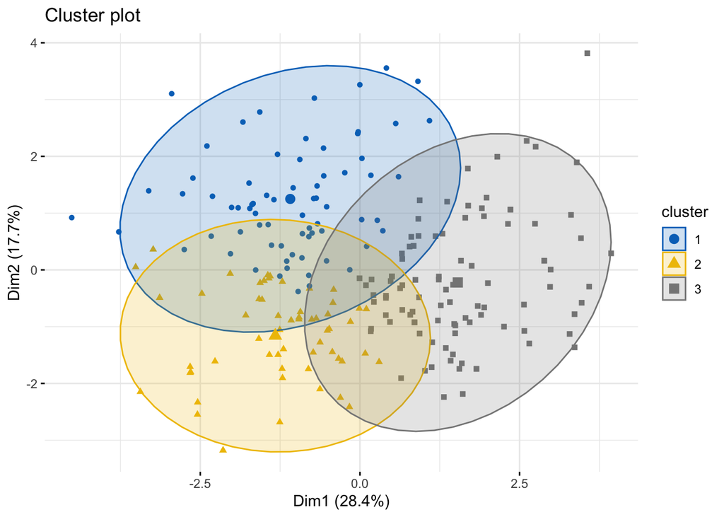

```r
# K-means clustering
km.res <- eclust(stdata, "kmeans", k = 3, nstart = 25, graph = FALSE)
# Visualize k-means clusters
fviz_cluster(km.res, geom = "point", ellipse.type = "norm",
             palette = "jco", ggtheme = theme_minimal())
```

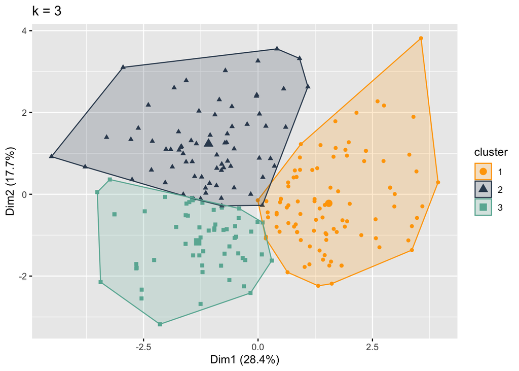

```r
fviz_cluster(fit2, geom = "point", data = stdata, outlier.color = "black", palette = dani) + ggtitle("k = 3")
```

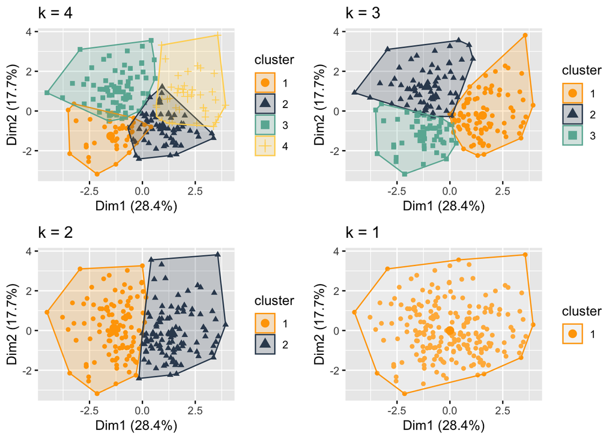

```r
p1 <- fviz_cluster(fit, geom = "point", data = stdata, outlier.color = "black", palette = dani) + ggtitle("k = 4")

p2 <- fviz_cluster(fit2, geom = "point", data = stdata, outlier.color = "black", palette = dani) + ggtitle("k = 3")

p3 <- fviz_cluster(fit3, geom = "point", data = stdata, outlier.color = "black", palette = dani) + ggtitle("k = 2")

p4 <- fviz_cluster(fit4, geom = "point", data = stdata, outlier.color = "black", palette = dani) + ggtitle("k = 1")

grid.arrange(p1, p2, p3, p4, nrow = 2)
```

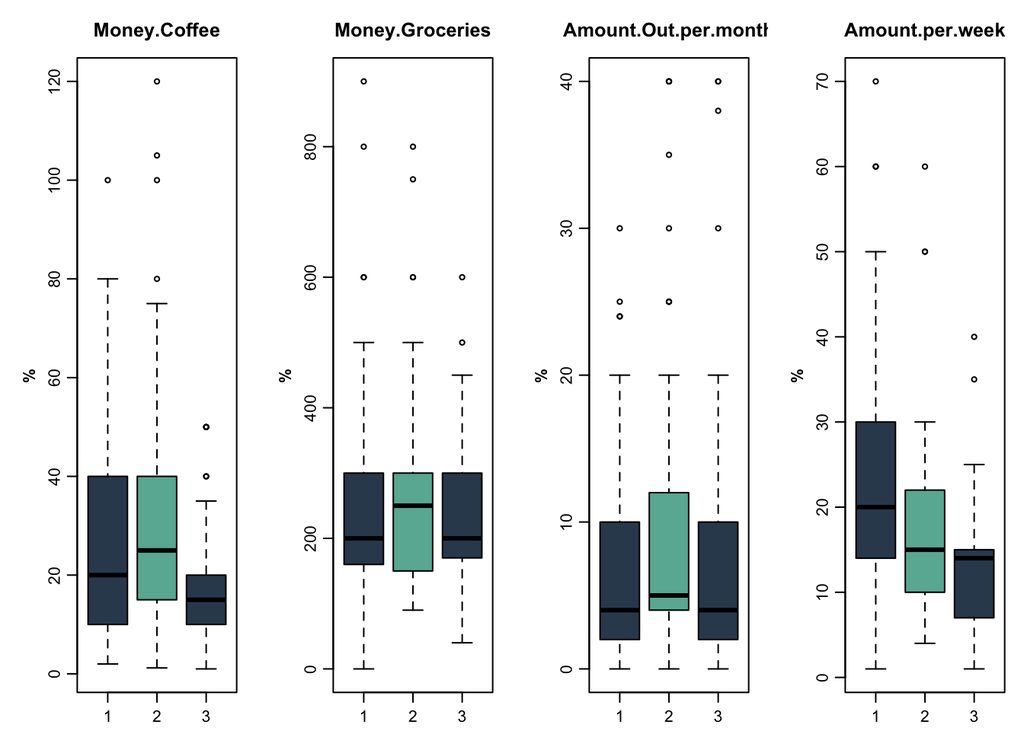

```r
Subdata <- data.frame("Money Coffee" = clustereddata$MoneyCoffee, "Money Groceries" = clustereddata$MoneyGroceries, "Amount Out per month" = clustereddata$AmountOutMonth, 'Amount per week' = clustereddata$AmountWeek)

par(mar=c(2,4,3,1), font.lab=2, mfrow=c(1,4), mgp=c(2,0.7,0))
for(j in 1:4) boxplot(Subdata[,j] ~ clustereddata$Cluster, main=colnames(Subdata)[j],
                      col=c("#34495E", "#69b3a2"), ylab="%")
```

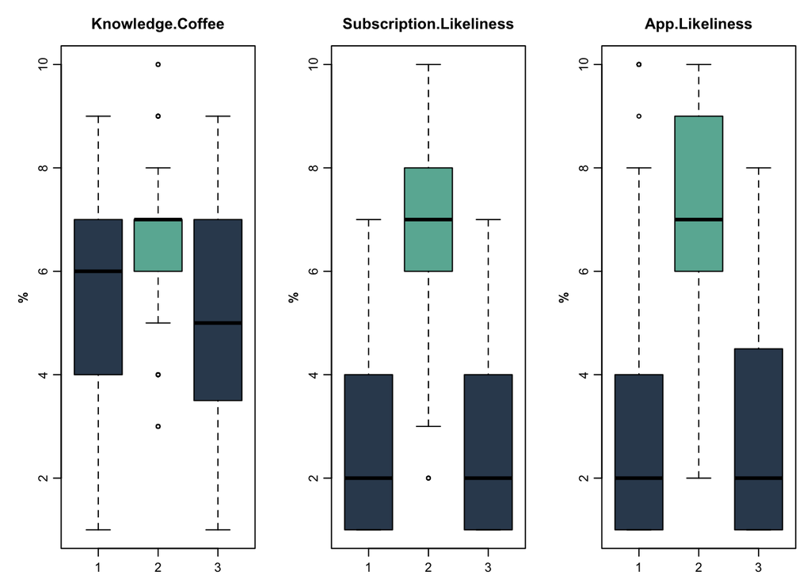

```r
Subdata <- data.frame("Knowledge Coffee" = clustereddata$KnowledgeCoffee, 'Subscription Likeliness' = clustereddata$Subscription_Likely, "App Likeliness" = clustereddata$App_Likely)

par(mar=c(2,4,3,1), font.lab=2, mfrow=c(1,3), mgp=c(2,0.7,0))
for(j in 1:3) boxplot(Subdata[,j] ~ clustereddata$Cluster, main=colnames(Subdata)[j],
                      col=c("#34495E", "#69b3a2"), ylab="%")
```

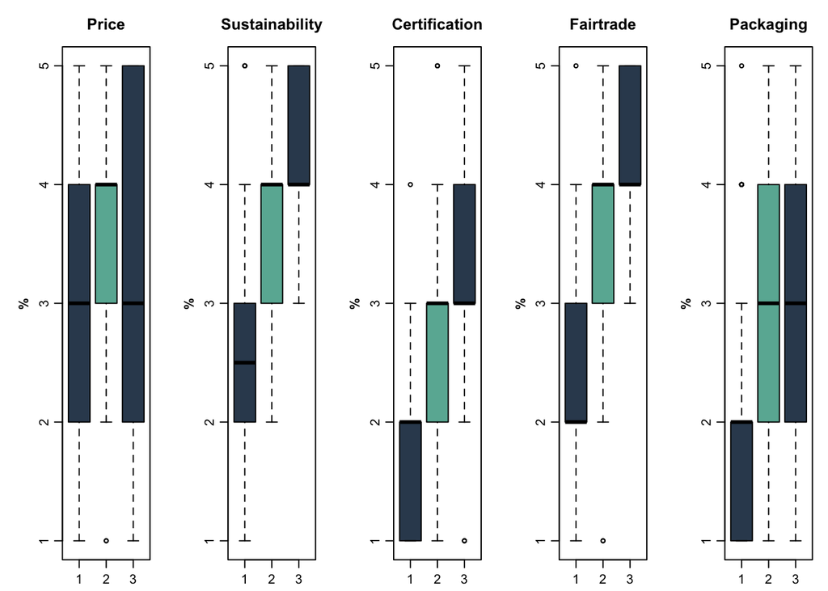

```r
Subdata <- data.frame(Price = clustereddata$Purchase_Price, Sustainability = clustereddata$Purchase_Sustainability, Certification = clustereddata$Purchase_Certificate, Fairtrade = clustereddata$Purchase_Fairtrade, Packaging = clustereddata$Purchase_Packaging)

par(mar=c(2,4,3,1), font.lab=2, mfrow=c(1,5), mgp=c(2,0.7,0))
for(j in 1:5) boxplot(Subdata[,j] ~ clustereddata$Cluster, main=colnames(Subdata)[j],
                      col=c("#34495E", "#69b3a2"), ylab="%")
```

## Robustness check

### The clusters individual results

```r
data <- read_excel("Main doc survey.xlsx")
clustereddata <- cbind(data, Cluster = fit2$cluster)

cluster1 <- subset(clustereddata, clustereddata$Cluster=='1')
cluster2 <- subset(clustereddata, clustereddata$Cluster=='2')
cluster3 <- subset(clustereddata, clustereddata$Cluster=='3')
```

```r
Results <- as.data.table(aggregate(na.omit(clustereddata[,2:5]), by=list(cluster=fit2$cluster), mean), by = round)

Results_Round <- round(Results)
my_table(Results_Round)
```

| cluster | AmountWeek | AmountOutMonth | MoneyCoffee | MoneyGroceries |
| --- | --- | --- | --- | --- |
| 1 | 22 | 7 | 26 | 242 |
| 2 | 18 | 10 | 31 | 263 |
| 3 | 13 | 7 | 17 | 238 |

```r
Results <- as.data.table(aggregate(na.omit(clustereddata[,c(12,19)]), by=list(cluster=fit2$cluster), median), by = round)

Results_Round <- round(Results,1)

my_table(Results_Round)
```

| cluster | KnowledgeCoffee | Subscription_Likely |
| --- | --- | --- |
| 1 | 6 | 2 |
| 2 | 7 | 7 |
| 3 | 5 | 2 |

```r
Results <- as.data.table(aggregate(na.omit(clustereddata[,13:17]), by=list(cluster=clustereddata$Cluster), median), by = round)

Results_Round <- round(Results)
my_table(Results_Round)
```

| cluster | Purchase_Price | Purchase_Sustainability | Purchase_Certificate | Purchase_Fairtrade | Purchase_Packaging |
| --- | --- | --- | --- | --- | --- |
| 1 | 3 | 2 | 2 | 2 | 2 |
| 2 | 4 | 4 | 3 | 4 | 3 |
| 3 | 3 | 4 | 3 | 4 | 3 |

```r
agetable1 <- as.data.table(table(cluster1$AgeCategory))
colnames(agetable1) <- c("Age", "Frequency")

agetable2 <- as.data.table(table(cluster2$AgeCategory) )
colnames(agetable2) <- c("Age", "Frequency")

agetable3 <- as.data.table(table(cluster3$AgeCategory) )
colnames(agetable3) <- c("Age", "Frequency")

my_table(agetable1)
```

| Age | Frequency |
| --- | --- |
| > 60 | 9 |
| 18-25 | 24 |
| 25-45 | 40 |
| 45-60 | 29 |

```r
my_table(agetable2)
```

| Age | Frequency |
| --- | --- |
| > 60 | 1 |
| 18-25 | 31 |
| 25-45 | 31 |
| 45-60 | 11 |

```r
my_table(agetable3)
```

| Age | Frequency |
| --- | --- |
| < 18 | 2 |
| > 60 | 1 |
| 18-25 | 17 |
| 25-45 | 30 |
| 45-60 | 9 |

```r
table1 <- as.data.table(table(cluster1$Machine))
colnames(table1) <- c("Machine", "Frequency")

table2 <- as.data.table(table(cluster2$Machine) )
colnames(table2) <- c("Machine", "Frequency")

table3 <- as.data.table(table(cluster3$Machine) )
colnames(table3) <- c("Machine", "Frequency")

my_table(table1)
```

| Machine | Frequency |
| --- | --- |
| CupMachine | 41 |
| Espresso machine | 27 |
| Filter machine | 24 |
| French press | 2 |
| Instant coffee | 3 |
| Moka pot | 5 |

```r
my_table(table2)
```

| Machine | Frequency |
| --- | --- |
| Aeropress | 1 |
| CupMachine | 19 |
| Espresso machine | 35 |
| Filter machine | 7 |
| French press | 2 |
| Instant coffee | 1 |
| Moka pot | 5 |
| V60 | 4 |

```r
my_table(table3)
```

| Machine | Frequency |
| --- | --- |
| CupMachine | 14 |
| Espresso machine | 13 |
| Filter machine | 17 |
| French press | 5 |
| Instant coffee | 1 |
| Moka pot | 8 |
| Percolator | 1 |

```r
table1 <- as.data.table(table(cluster1$PurchaseLocation))
colnames(table1) <- c("PurchaseLocation", "Frequency")

table2 <- as.data.table(table(cluster2$PurchaseLocation) )
colnames(table2) <- c("PurchaseLocation", "Frequency")

table3 <- as.data.table(table(cluster3$PurchaseLocation) )
colnames(table3) <- c("PurchaseLocation", "Frequency")

my_table(table1)
```

| PurchaseLocation | Frequency |
| --- | --- |
| E-commerce | 17 |
| Online subscription | 3 |
| Specialty stores or cafés | 5 |
| The supermarket | 77 |

```r
my_table(table2)
```

| PurchaseLocation | Frequency |
| --- | --- |
| E-commerce | 14 |
| Online subscription | 10 |
| Specialty stores or cafés | 18 |
| The supermarket | 32 |

```r
my_table(table3)
```

| PurchaseLocation | Frequency |
| --- | --- |
| E-commerce | 9 |
| Online subscription | 1 |
| Specialty stores or cafés | 6 |
| The supermarket | 43 |

```r
table1 <- as.data.table(table(cluster1$Frequency_Specialty))
colnames(table1) <- c("PurchaseLocation", "Frequency")

table2 <- as.data.table(table(cluster2$Frequency_Specialty) )
colnames(table2) <- c("Frequency_Specialty", "Frequency")

table3 <- as.data.table(table(cluster3$Frequency_Specialty) )
colnames(table3) <- c("Frequency_Specialty", "Frequency")

my_table(table1)
```

| PurchaseLocation | Frequency |
| --- | --- |
| Always | 4 |
| I do (did) not know what this is | 32 |
| Never | 25 |
| Only in cafes | 20 |
| Sometimes | 21 |

```r
my_table(table2)
```

| Frequency_Specialty | Frequency |
| --- | --- |
| Always | 18 |
| I do (did) not know what this is | 6 |
| Never | 4 |
| Only in cafes | 16 |
| Sometimes | 30 |

```r
my_table(table3)
```

| Frequency_Specialty | Frequency |
| --- | --- |
| Always | 7 |
| I do (did) not know what this is | 17 |
| Never | 12 |
| Only in cafes | 11 |
| Sometimes | 12 |

# Clusters groups

```r
data <- read_excel("Main doc survey.xlsx")
clustereddata <- cbind(data, Cluster = fit2$cluster)

cluster1 <- clustereddata[clustereddata$Cluster=='1',]
cluster2 <- clustereddata[clustereddata$Cluster=='2',]
cluster3 <- clustereddata[clustereddata$Cluster=='3',]
```

## Cluster 1 medians

```r
var_names <- colnames(cluster1[,-ncol(cluster1)])

medians1 <- list()
for (var_name in var_names) {
  medians1[[var_name]] <- median(get(var_name), data=cluster1)
}

medians1
```

```
$Participant
[1] 118

$AmountWeek
[1] 15

$AmountOutMonth
[1] 5

$MoneyCoffee
[1] 20

$MoneyGroceries
[1] 200

$Machine
[1] "Espresso machine"

$BrandChange
[1] "Sometimes"

$PurchaseLocation
[1] "The supermarket"

$`Supermarket_Positive_ Reasons`
[1] "I do not purchase coffee from the supermarket"

$`Supermarket_Negative_ Reasons`
[1] "No reason"

$Criteria_Type_Coffee
[1] "Price, Arabica or Robusta"

$KnowledgeCoffee
[1] 6

$Purchase_Price
[1] 3

$Purchase_Sustainability
```

[output cut: 25 more lines]

```

$AgeCategory
[1] "25-45"

$Occupation
[1] "Employed (Full time)"

$Education
[1] "Bachelor's degree"

$Home
[1] "Urban (City)"

$Language
[1] "Dutch"
```

## Cluster 2 medians

```r
var_names <- colnames(cluster2[,-ncol(cluster2)])

medians2 <- list()
for (var_name in var_names) {
  medians2[[var_name]] <- median(get(var_name), data = cluster2)
}

medians2
```

[output not shown]

[output cut: 25 more lines]

```

$AgeCategory
[1] "25-45"

$Occupation
[1] "Employed (Full time)"

$Education
[1] "Bachelor's degree"

$Home
[1] "Urban (City)"

$Language
[1] "Dutch"
```

## Cluster 3 medians

```r
var_names <- colnames(cluster3[,-ncol(cluster3)])

medians3 <- list()
for (var_name in var_names) {
  medians3[[var_name]] <- median(get(var_name))
}

medians3
```

[output not shown]

[output cut: 25 more lines]

```

$AgeCategory
[1] "25-45"

$Occupation
[1] "Employed (Full time)"

$Education
[1] "Bachelor's degree"

$Home
[1] "Urban (City)"

$Language
[1] "Dutch"
```

## Appendices

Data set

| Field | Description | Scales |
| --- | --- | --- |
| AmountWeek | How many cups of coffee do you typically consume weekly? | Ratio, Continous |
| AmountOutMonth | How frequently do you drink out-of-home per month on average? | Ratio, Continous |
| MoneyCoffee | How much money on average do you estimate you spend on coffee per month? | Ratio, Continous |
| MoneyGroceries | How much on average do you spend on general groceries per month? | Ratio, Continous |
| Machine | How do you brew your coffee at home? | Nominal |
| Brand change | How often do you switch between coffee brands? | Nominal |
| Purchase location | Where do you usually purchase your coffee? | Nominal |
| Supermarket_Positive_Reasons | When you purchase coffee from the supermarket what are your main reasons for doing so? | Nominal |
| Supermarket_Negative_Reasons | What would be reasons why you would not purchase coffee from the supermarket? | Nominal |
| Criteria_Type_Coffee | What are your main criteria’s or evaluation points for choosing the type of coffee? | Nominal |
| KnowledgeCoffee | How would you describe your knowledge level regarding coffee in general? | Ordinal. 0-10, Discrete |
| Purchase_Price | I believe that the ____ is important to my decision on which coffee to purchase. | Ordinal, likert 0-5 |
| Purchase_Sustainability | I believe that the ____ is important to my decision on which coffee to purchase. | Ordinal, likert 0-5 |
| Purchase_Sustainability | I believe that the ____ is important to my decision on which coffee to purchase. | Ordinal, likert 0-5 |
| Purchase_Fairtrade | I believe that the ____ is important to my decision on which coffee to purchase. | Ordinal, likert 0-5 |
| Purchase_Packaging | I believe that the ____ is important to my decision on which coffee to purchase. | Ordinal, likert 0-5 |
| Frequency_Specialty | How often do you drink specialty coffee? | Ordinal |
| Subscription_Likely | How likely are you to have an online subscription for (specialty) coffee? | Ordinal 0-10, Discrete |
| Subscription_Not_Likely | What is the number one reasons why you would be hesitant? | Nominal |
| App_Likely | How likely are you to value and use an app for your online subscription? | Ordinal, 0-10, Discrete |
| Gender | What is your gender? | Nominal |
| AgeCategory | What is your age category? | Ordinal |
| Occupation | What is your occupational status? | Nominal |
| Education | What level of education have you completed? | Ordinal |
| Home | How would you describe the place you currently live in? | Nominal |

## References

https://towardsdatascience.com/clustering-analysis-in-r-using-k-means-73eca4fb7967

http://www.sthda.com/english/articles/31-principal-component-methods-in-r-practical-guide/112-pca-principal-component-analysis-essentials/